# Part II - (Analysis of bike rides in bike sharing system)

## by (Navya)

## Investigation Overview

> The main investigation is at what hour,day,month of the year most trips are made and how the duration of the trip is related to other variables like user type,gender etc.

## Dataset Overview

> This data set includes information about 183412 individual rides made in a bike-sharing system covering the greater San Francisco Bay area. The dataset originally contains 183412 rows and 16 columns. After wrangling and cleaning the dataset,it now contains 174952 rows and 24 columns.The columns include start time,start station and their coordinates,end time,end station and their coordinates,bike id,user type etc.

## (Visualization 1)

### Ride frequency by hours of day

#### Both the plots are multimodal distributions.The 8th,9th,17th and 18th hours have the highest number of trips. The 3rd,4th trips have the least number of trips.

### Key Insight:

#### This clearly tells there are high number of rides during the opening office hours and closing office hours.

```
Text(0.5,1,'Frequency of bike rides based on end hour of the day')
```

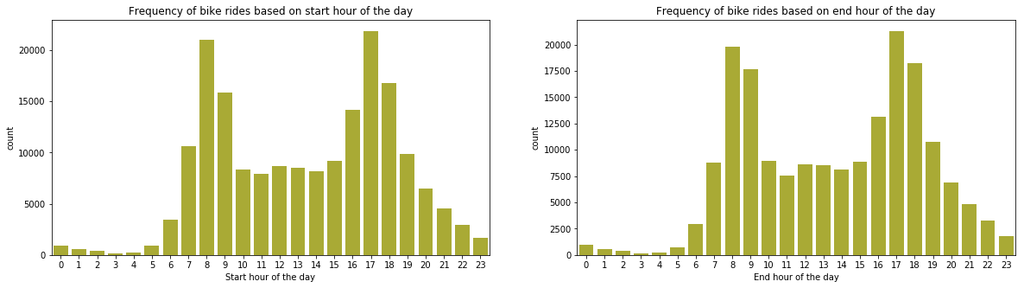

## (Visualization 2)

### Ride frequency and duration of trip based on gender

### Key Insight:

#### Though the number of higher duration trips is more for male riders but time of duration is higher for women and others.

```
Text(0.5,1,'Duration of the trip based on gender')
```

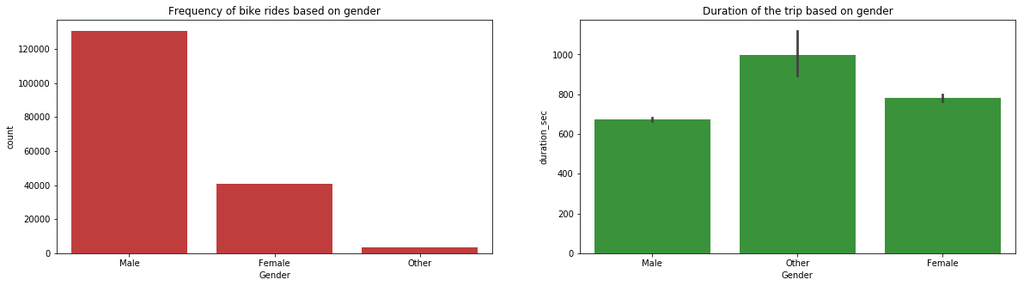

## (Visualization 3)

### Ride frequency and duration of trip based on user type

#### Customers travel longer distances on all days of the week whereas subscribers travel shorter distances.Both the user types travel more distances on weekends than on week days. However, number of trips varies exactly opposite.

### Key Insight:

#### Customers travel longer distances than subscribers though the number of trips are only 10% of subscribers.

[figure not shown]